# Part II - (Investigating Trip features)

## by (Aleke Ezekiel Victor)

## Investigation Overview

> I intended to look at the trip data characteristics that could be used to forecast their duration in this inquiry. Age, start station, finish station, user type, and gender were given the most attention.

## Dataset Overview

> The data consists of duration_sec, age and user_type with 183,412. The attributes included the five, as well as additional measurements such as start station name, start station latitude, and start station longitude.

## Distribution of Trip Durations

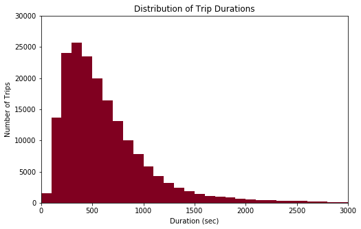

## Distribution of User Age

In the case of age, the distribution is more concentrated between 20 to 40 years old.

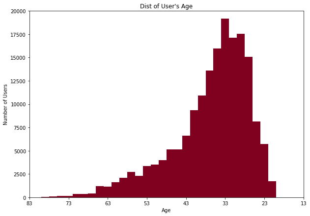

## Trip Duration by Age

Frequent duration is registered by younger members between 20 and 45.

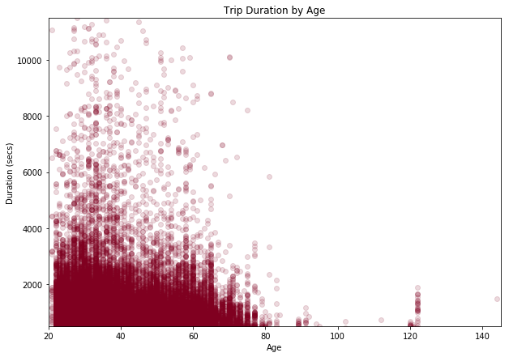

## Trip Duration by Age and Gender

The main thing I want to explore in this part of the analysis is how the three categorical measures of gender into the relationship between trip duration and age.

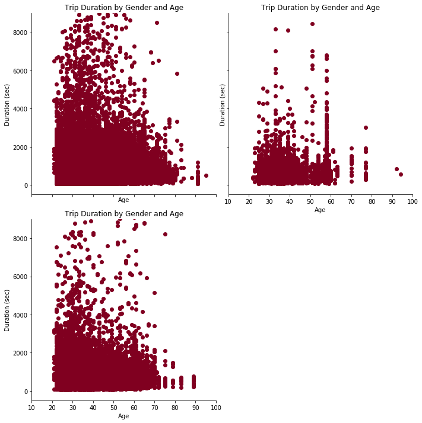

## Trip Duration by Age and User Type

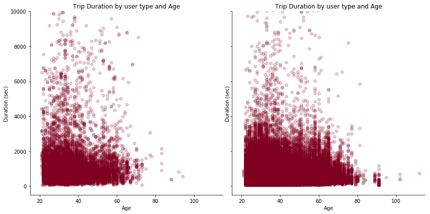